# 1.Welcome!!

This is **BUAN B493-W51 - Business Analytics Using Python**

Also known as- *Data Science for Business using Python*

# 1.1. Introductions

## 1.1.1. Student introductions

Love to know your motivation to take this course

1. Name, Major & Year
2. Why did you enroll in the course?
3. Have you used any data analysis program before?
4. What do you hope to acheive at the end of the course?

## 1.1.2. Instructor- ***Sumit Dhar***

1. 20 years in the Data Science/ Analytics Industry
2. Independent Industry Consultant & Data Scientist
3. Worked for start ups and large corporations in senior Data Science role
4. Worked for- MicroStrategy, Cap Gemini- Sogeti, GE, BarclayCard, 24/7 iLabs
5. Banks: Marketing & Risk Analytics || Online Experiene Analytics || IoT/ Device Analytics
6. My Motivation in teaching the course- connect with local University and students

## 1.1.3. Introducing the course

- 100% online class
- This is a first course in Python and Data Science
  - **'101'** skills that can be developed further
- The course is going to be taught out of ipython notebooks and google colab IDE. No powerpoint etc
- Course materials ca be accessed online and all codes can be executed as shown in the class
- **Learn through doing**
  - By doing Data Science hands down
  - By attmepting to solve data analysis problems through coding
  - Collaborate and Co-opertive in the class and outside while being safe [as long as it doesn't violate the clauses of plagiarism at Loyola University]
  - Research, experiement and trial
- Class Material freely available; Online resources weaved into class notes.
- No group assignment

# 1.2 The Data Science Process

[Reference Article](https://www.kdnuggets.com/2016/03/data-science-process-rediscovered.html)

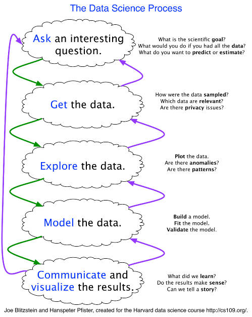

```python
from IPython.core.display import Image, display
display(Image('https://www.kdnuggets.com/wp-content/uploads/data-science-process.jpg', width=800, height=800))
```

# 1.3 Making sense of the Landscape

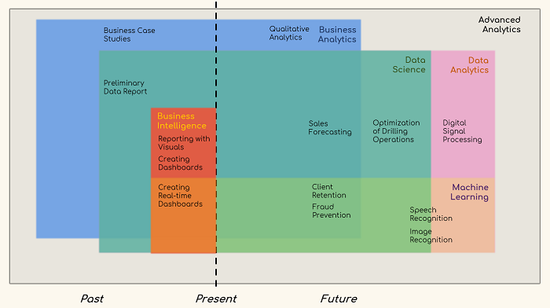

```python
from IPython.display import Image
Image("https://www.kdnuggets.com/wp-content/uploads/data-science-fig-1.png")
```

More details in this [article](https://www.kdnuggets.com/2018/05/data-science-machine-learning-business-analytics.html)

# 1.4 Data Science Tech Stack

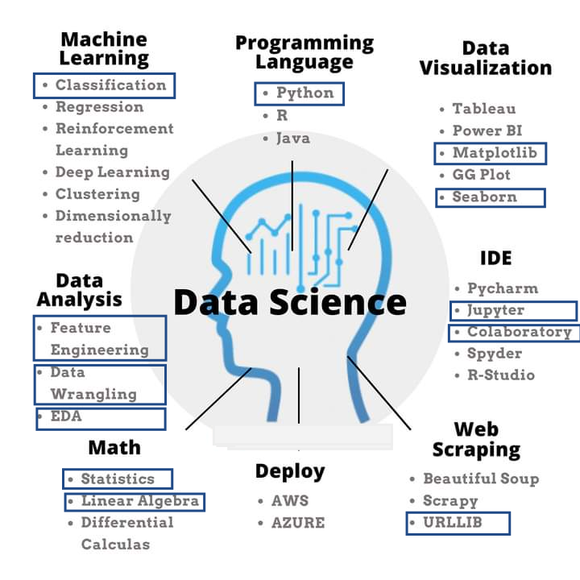

```python
link= 'https://raw.githubusercontent.com/sdhar-pycourse/py-datascience-biz/main/images/coverage.png'
from IPython.display import Image
Image(link)
```

# 1.5 Python for Data Science

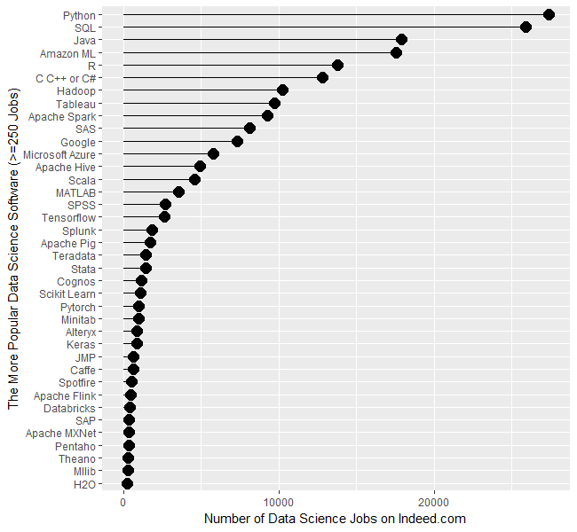

```python
link= 'https://i2.wp.com/r4stats.com/wp-content/uploads/2019/05/Fig-1a-IndeedJobs-2019-1.png'
from IPython.display import Image
Image(link)
```

## 1.5.1. History of Python programming language

[On Quora](https://www.quora.com/Why-is-Python-a-language-of-choice-for-data-scientists) brief history of evolution of Python as a scientific language of choice

- Python is an interpreted, dynamically-typed language with a precise and efficient syntax.
- Python has a good **REPL** and new modules can be explored from the **REPL** with dir() and docstrings. That's one reason to prefer Python over C, C++, or Java.
- The Python community invested in the mid-1990s in Numeric, an *"extension to Python to support numeric analysis as naturally as Matlab does"*
- Numeric later evolved into NumPy
- Several years later, the plotting functionality from Matlab was ported to Python with matplotlib.
  - Libraries for scientific computing were built around NumPy and matplotlib and bundled into the SciPy package

## 1.5.1. Using Google Colab

- Out o the box Python Notebook environment
- All work and Files saved in google drive!!
- Here is a brief overview- [How to use Google Colab](https://www.geeksforgeeks.org/how-to-use-google-colab/)

# FREE Resources

## Books & Such

- You don't need these to pass the course.
- Sharing these Python and Data Science Resources such that you can increase your knowledge beyond the course content
1. [The Hitchhiker’s Guide to Python!](https://docs.python-guide.org/)
2. [Automate the Boring Stuff with Python](https://automatetheboringstuff.com/2e/chapter1/)
3. [Python for Everybody](https://www.py4e.com/book.php)
4. [Python Data Science Handbook](https://jakevdp.github.io/PythonDataScienceHandbook/)

## Websites

1. https://www.python.org/
2. https://www.python.org/community/
3. https://stackify.com/learn-python-tutorials/
4. https://stackoverflow.com/
5. https://www.fullstackpython.com/python-community.html

# APPENDIX- A

Installing Python IDE on your desktops:

- [Anaconda](https://docs.anaconda.com/anaconda/install/)
- [PyCharm](https://www.jetbrains.com/help/pycharm/installation-guide.html)